# Bioinformatics Lab2

Milda Poceviciute

24 November 2018

# Question 1: DNA sequence acquisition and simulation

```r
lizards_sequences<-ape::read.FASTA("lizard_seqs.fasta")
```

## Q1.1

In this part we simulate DNA sequences with the same base composition and sequences length as the one from the GenBank:

```r
len_list <- lengths(lizards_sequences)
new_seq_list <- list()
new_seq <- c()
for (i in 1:length(lizards_sequences)){
    # extract the base composition of each sequence
    freqx <- ape::base.freq(lizards_sequences[i])
    new_seq <- sample(c("a","c","g","t"),len_list[i],rep=TRUE,prob=freqx)
    new_seq_list[i] <- list(new_seq)
}

# convert result to the DNAbin class
simulated_seq1 <- as.DNAbin(new_seq_list)
names(simulated_seq1) <- names(lizards_sequences)
```

```
## Base composition of the data from GenBank:
```

```
##         a         c         g         t
## 0.3121454 0.2052325 0.2307222 0.2518999
```

```
## Base composition of the simulated sequences:
```

```
##         a         c         g         t
## 0.3098495 0.2059448 0.2342630 0.2499427
```

We can see that the original data, and the simulated data have quite similar base compositions.

## Q1.2

In this part we simulate another set of DNA data with similar characteristics as the original one. Now we use a simulated tree with 33 nodes from the original data and package phangorn to do this:

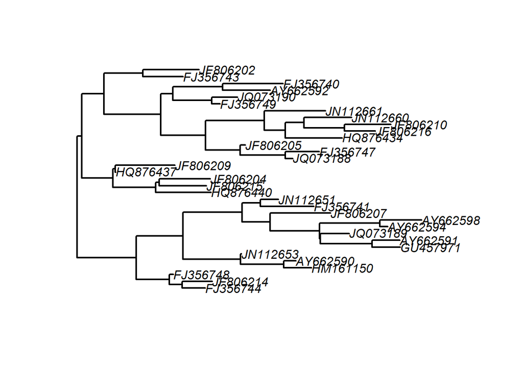

```r
# Simulate a tree with 33 nodes
tree <- rtree(n = 33, rooted = TRUE, tip.label = names(lizards_sequences) )
plot(tree, edge.width = 2)
```

We need to create a transition matrix, so we use the full dataset to compute that:

```r
data <- c()
simulated_seq_tree <- list()

DNA_list <- unlist(as.character(lizards_sequences),use.names = FALSE)
DNA_unique <- c("a","c","g","t")
matrix <-  matrix(0, ncol = length(DNA_unique),
                  nrow = length(DNA_unique))

for (i in 1:(length(DNA_list) - 1)) {
    index_of_i <- DNA_unique == DNA_list[i]
    index_of_i_plus_1 <- DNA_unique == DNA_list[i + 1]
    matrix[index_of_i, index_of_i_plus_1] = matrix[index_of_i, index_of_i_plus_1] + 1
}

# Transition matrix is finally computed
Q <- matrix / rowSums(matrix)
Q_lower <- Q[lower.tri(Q)]
# Other parameters that are needed for phangorn package function
bf <-  ape::base.freq(lizards_sequences)
size <- round(mean(len_list))
```

```r
# Generating the data based on the tree

simulated_seq_tree <-  phangorn::simSeq(
        tree,
        l = size,
        type = "DNA",
        bf = bf,
        Q = Q_lower)

# change numbers into letters
simulated_seq_tree2 <- lapply(simulated_seq_tree,function(seq){
    #seq = a
    states = c("a","c","g","t")
    seq[which(seq==1)] <- states[1]
    seq[which(seq==2)] <- states[2]
    seq[which(seq==3)] <- states[3]
    seq[which(seq==4)] <- states[4]
    return(seq)
})

simulated_seq2 <- as.DNAbin(simulated_seq_tree2)
# Write the simulated sequence to a fasta file
#ape::write.dna(simulated_seq2, file ="lizard_sim_seqs.fasta", format = "fasta", append =FALSE, nbcol = 6, colsep = " ", colw = 10)
```

```
## Base composition of the data from GenBank:
```

```
##         a         c         g         t
## 0.3121454 0.2052325 0.2307222 0.2518999
```

```
## Base composition of the simulated sequences Q1.1:
```

```
##         a         c         g         t
## 0.3098495 0.2059448 0.2342630 0.2499427
```

```
## Base composition of the simulated sequences Q1.2:
```

```
##         a         c         g         t
## 0.3087150 0.2058864 0.2317273 0.2536714
```

# Question 2: Sequence analysis

## Q2.1

```
## Individual base composition of sequence 1
## The data from the GenBank:
##         a         c         g         t
## 0.2898696 0.2026078 0.2437312 0.2637914
## The simulated data in Q1.1:
##         a         c         g         t
## 0.2835671 0.2084168 0.2625251 0.2454910
## The simulated data in Q1.2:
##         a         c         g         t
## 0.3161876 0.1976803 0.2425618 0.2435703
##
## Individual base composition of sequence 2
## The data from the GenBank:
##         a         c         g         t
## 0.3115541 0.2122554 0.2314507 0.2447398
## The simulated data in Q1.1:
##         a         c         g         t
## 0.3060170 0.2181617 0.2377261 0.2380952
## The simulated data in Q1.2:
##         a         c         g         t
## 0.3025719 0.1981846 0.2400403 0.2592032
##
## Individual base composition of sequence 3
## The data from the GenBank:
##         a         c         g         t
## 0.3130405 0.2099620 0.2348668 0.2421308
## The simulated data in Q1.1:
##         a         c         g         t
## 0.3199585 0.2044275 0.2386717 0.2369422
## The simulated data in Q1.2:
##         a         c         g         t
## 0.3126576 0.1946546 0.2365103 0.2561775
##
## Individual base composition of sequence 4
## The data from the GenBank:
##         a         c         g         t
## 0.2842942 0.2097416 0.2445328 0.2614314
## The simulated data in Q1.1:
##         a         c         g         t
## 0.2804757 0.2309217 0.2566898 0.2319128
```

[output cut: 307 more lines]

```
## 0.3100698 0.1874377 0.2422732 0.2602193
## The simulated data in Q1.2:
##         a         c         g         t
## 0.3081190 0.2097832 0.2228946 0.2592032
##
## Individual base composition of sequence 33
## The data from the GenBank:
##         a         c         g         t
## 0.2932331 0.2030075 0.2406015 0.2631579
## The simulated data in Q1.1:
##         a         c         g         t
## 0.2824919 0.1944146 0.2599356 0.2631579
## The simulated data in Q1.2:
##         a         c         g         t
## 0.3146747 0.2178517 0.2188603 0.2486132
```

The CG contents are:

```
## In the data from the GenBank:
```

```
## [1] 0.4359547
```

```
## In the simulated data in Q1.1:
```

```
## [1] 0.4402078
```

```
## In the simulated data in Q1.2:
```

```
## [1] 0.4376137
```

A,C,G,T contents are:

```r
# A,C,G,T content
cat("In the data from the GenBank:")
```

```
## In the data from the GenBank:
```

```r
cat("\n")
```

```r
print(ape::base.freq(lizards_sequences))
```

```
##         a         c         g         t
## 0.3121454 0.2052325 0.2307222 0.2518999
```

```r
cat("In the simulated data in Q1.1:")
```

```
## In the simulated data in Q1.1:
```

```r
cat("\n")
```

```r
print(ape::base.freq(simulated_seq1))
```

```
##         a         c         g         t
## 0.3098495 0.2059448 0.2342630 0.2499427
```

```r
cat("In the simulated data in Q1.2:")
```

```
## In the simulated data in Q1.2:
```

```r
cat("\n")
```

```r
print(ape::base.freq(simulated_seq2))
```

```
##         a         c         g         t
## 0.3087150 0.2058864 0.2317273 0.2536714
```

The nucleotide sequences were transformed into amino acid sequences using the EMBOSS Transeq function, and saved to a fasta file:

```r
amino_lizard_seq <- read.fasta("lizard_amino_seqs.fasta")
amino_sim1_seq <- read.fasta("sim1_amino_seq.fasta")
amino_sim2_seq <- read.fasta("lizard_amino_sim_seqs.fasta")
```

```r
find_stops <- function(a){
    stop <- a[which(a == "*")]
    return(length(stop))
}
stop_codons_lizard <- lapply(amino_lizard_seq,find_stops)
stop_codons_sim1 <- lapply(amino_sim1_seq,find_stops)
stop_codons_sim2 <- lapply(amino_sim2_seq,find_stops)
```

## Q2.2

In this part we do markov chain analysis of the data sets. We combine all the sequences from each dataset to seperate lists, and use the *markovchainFit* function with bootstrapping to estimate the Markov models. This function fits the first order markov model to all three datasets.

```r
lizard <- as.character(lizards_sequences)
sim1 <- as.character(simulated_seq1)
sim2 <- as.character(simulated_seq2)


flat_lizard <- unlist(lizard,use.names = FALSE)
mc_lizard <-  markovchainFit(flat_lizard,method = "bootstrap", nboot = 3, name = "Bootstrap Mc")

# the original data contains some "weird nucleotides" - what to do with them?
which(flat_lizard == "y")
```

```
##  [1]   269  6787 21562 21706 21859 22675 23419 28171 30281 31547 33732
## [12] 37937 45594 56259 58504
```

```r
which(flat_lizard == "m")
```

```
## [1] 21470 38532 45235
```

```r
which(flat_lizard == "r")
```

```
##  [1]  6653  6836 21395 21582 23621 26779 30533 32015 32784 36968 37225
## [12] 44900 46386 54146 54560 56322 61914
```

```r
which(flat_lizard == "s")
```

```
## [1] 54451
```

```r
flat_sim1 <- unlist(sim1,use.names = FALSE)
mc_sim1 <-  markovchainFit(flat_sim1,method = "bootstrap", nboot = 3, name = "Bootstrap Mc")

flat_sim2 <- unlist(sim2,use.names = FALSE)
mc_sim2 <-  markovchainFit(flat_sim2,method = "bootstrap", nboot = 3, name = "Bootstrap Mc")

# comparison of the estimated transition matrices
#mc_lizard$estimate
#flat_sim1$estimate
#mc_sim2$estimate
Q
```

```
##          [,1]      [,2]       [,3]      [,4]
## [1,] 0.337859 0.1733654 0.27502206 0.2137536
## [2,] 0.379426 0.2479314 0.05024227 0.3224003
## [3,] 0.393646 0.2031571 0.19347350 0.2097234
## [4,] 0.150838 0.2118654 0.35711683 0.2801797
```

```r
#markovchainSequence() - can use markov model to predict a sequence
```

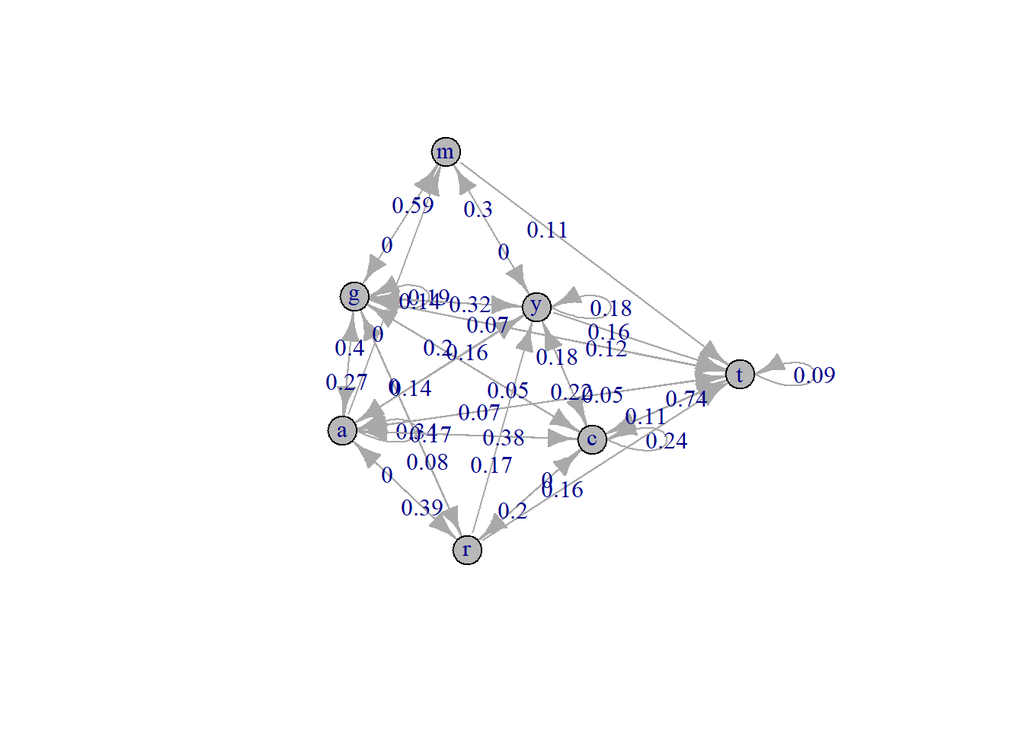

```r
plot(mc_lizard$estimate)
```

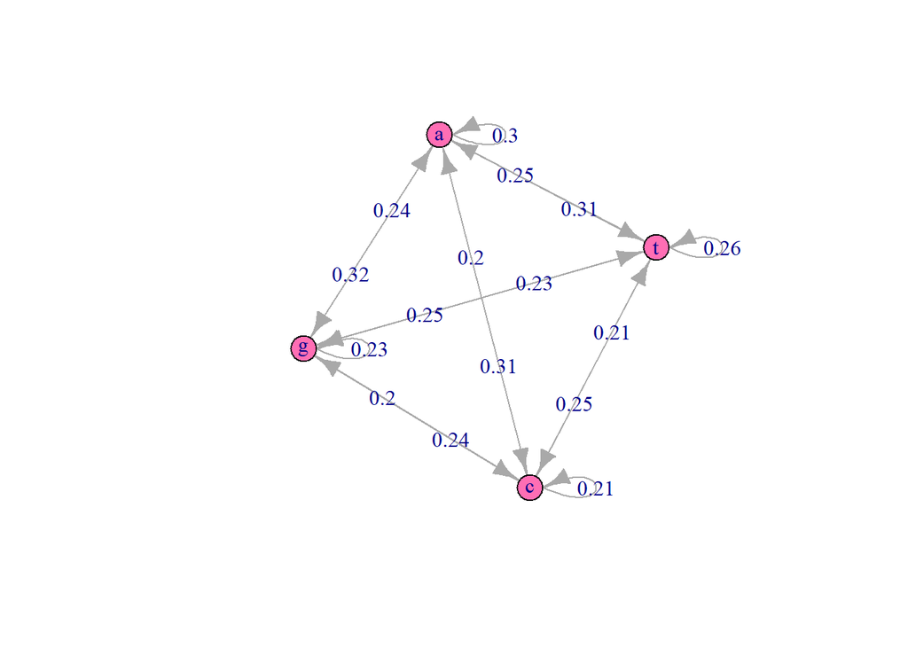

```r
plot(mc_sim1$estimate)
```

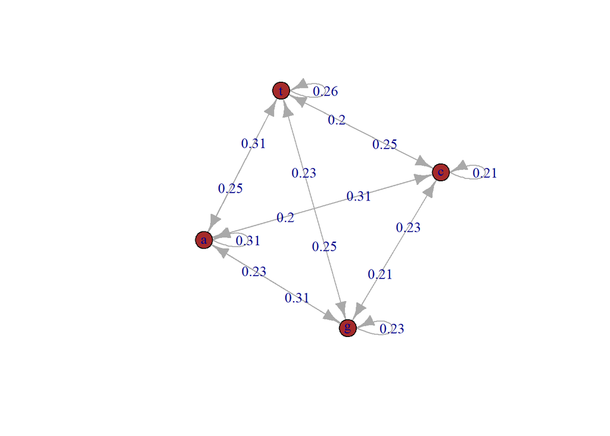

```r
plot(mc_sim2$estimate)
```

```r
# Results from the zero order
    # barplot(zeroOrderFreq,col=1:4,
    #         main="Compositional bias of each nucleotide\nZero Order Markov Chain",
    #         xlab="Base",
    #         ylab="Base proportion")
```

## Q2.3

In this part the three DNA collections of the sequences are aligned using the *msa* package. Furthermore the distances between the alignments are calculated. They are used to produce the heatmaps

```r
aligment_lizard <- msa("lizard_seqs.fasta", type="dna")
```

```
## use default substitution matrix
```

```r
aligment_sim1 <- msa("sim1_seq.fasta", type="dna")
```

```
## use default substitution matrix
```

```r
aligment_sim2 <- msa("lizard_sim_seqs.fasta", type="dna")
```

```
## use default substitution matrix
```

```r
aligment_lizard2 <- msaConvert(aligment_lizard, type="seqinr::alignment")
dist_lizard <- seqinr::dist.alignment(aligment_lizard2,matrix="identity")

aligment_sim1_2 <- msaConvert(aligment_sim1, type="seqinr::alignment")
dist_sim1 <- seqinr::dist.alignment(aligment_sim1_2,matrix="identity")

aligment_sim2_2 <- msaConvert(aligment_sim2, type="seqinr::alignment")
dist_sim2 <- seqinr::dist.alignment(aligment_sim2_2,matrix="identity")

# the seqinr::dist.alignment computes the square root distance
dm_lizard <- as.matrix(dist_lizard)
dm_sim1 <- as.matrix(dist_sim1)
dm_sim2 <- as.matrix(dist_sim2)
```

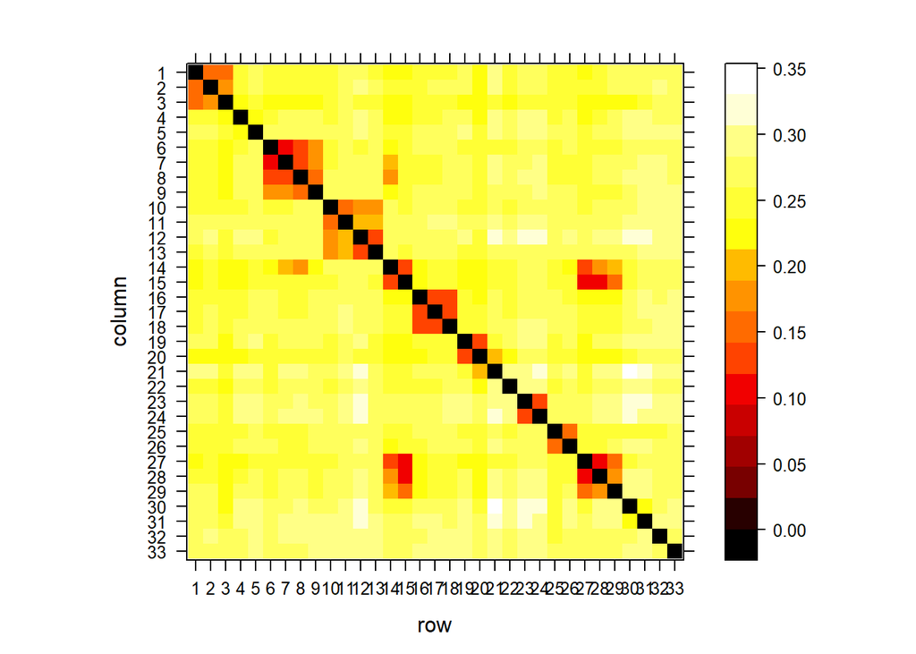

```r
# heatmaps
new.palette=colorRampPalette(c("black","red","yellow","white"),space="rgb")
levelplot(dm_lizard[1:ncol(dm_lizard),ncol(dm_lizard):1],col.regions=new.palette(20))
```

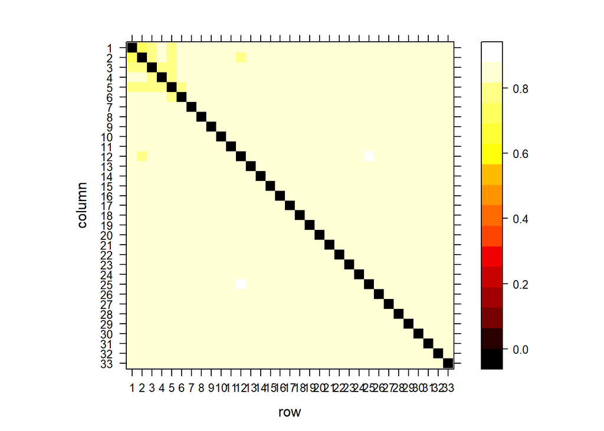

```r
levelplot(dm_sim1[1:ncol(dm_sim1),ncol(dm_sim1):1],col.regions=new.palette(20))
```

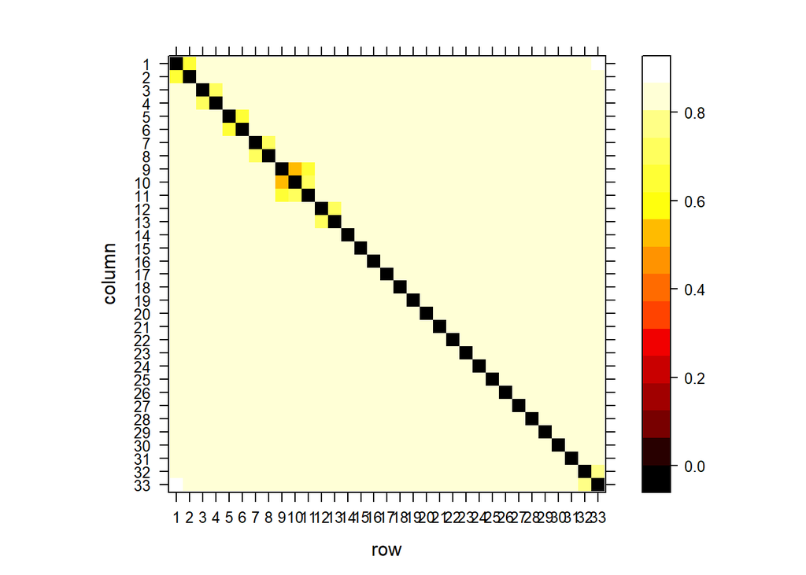

```r
levelplot(dm_sim2[1:ncol(dm_sim2),ncol(dm_sim2):1],col.regions=new.palette(20))
```

The plots illustrate how much overlaying the sequences have in each dataset. The smaller the value (the darker the colour), the more nucleotides are matching between the corresponding sequences of the DNA. Therefore, the sequences from the data from GenBank has much more overlaying parts then the two randomly generated sequences. This result is expected as sequencing of a DNA produces “fragments” of the real DNA sequence, and those “fragments” do contain the same bits of the original DNA. The artificially simulated DNA sequences did not actually go through a process of the sequencing, hence they are way less likely to randomly contain long matching parts in their sequences.